# MATH2270 Assignment 2

Visualising Open Data

## Student Details

- Student Name (s3644119)

## ## About

https://www.kaggle.com/zhangjuefei/birds-bones-and-living-habits

Context There are many kinds of birds: pigeons, ducks, ostriches, penguins… Some are good at flying, others can’t fly but run fast. Some swim under water, others wading in shallow pool.

## According to their living environments and living habits, birds are classified into different ecological groups. There are 8 ecological groups of birds:

- Swimming Birds
- Wading Birds
- Terrestrial Birds
- Raptors
- Scansorial Birds
- Singing Birds
- Cursorial Birds (not included in dataset)

## Marine Birds (not included in dataset)

First 6 groups are main and are covered by this dataset.

Apparently, birds belong to different ecological groups have different appearances: flying birds have strong wings and wading birds have long legs. Their living habits are somewhat reflected in their bones’ shapes. As data scientists we may think of examining the underlying relationship between sizes of bones and ecological groups , and recognising birds’ ecological groups by their bones’ shapes.

Content There are 420 birds contained in this dataset. Each bird is represented by 10 measurements (features): — * Length and Diameter of Humerus * Length and Diameter of Ulna * Length and Diameter of Femur * Length and Diameter of Tibiotarsus * Length and Diameter of Tarsometatarsus — All measurements are continuous float numbers (mm) with missing values represented by empty strings. The skeletons of this dataset are collections of Natural History Museum of Los Angeles County. They belong to 21 orders, 153 genera, 245 species.

## Each bird has a label for its ecological group

- SW: Swimming Birds
- W: Wading Birds
- T: Terrestrial Birds
- R: Raptors
- P: Scansorial Birds

## SO: Singing Birds

```r
# Load your packages
library(tidyr)
library(dplyr)
library(knitr)
library(GGally)
library(ggplot2)
library(ggridges)
```

## Data

```r
# Load your data and prepare for visualisation
birdDS <- read.csv("bird.csv")
```

## Exploring the Data

```r
# Load your data and prepare for visualisation
head(birdDS)
```

|  | id | huml | humw | ulnal | ulnaw | feml | femw | tibl | tibw | tarl | tarw | type |
| --- | --- | --- | --- | --- | --- | --- | --- | --- | --- | --- | --- | --- |
| 1 | 0 | 80.78 | 6.68 | 72.01 | 4.88 | 41.81 | 3.70 | 5.50 | 4.03 | 38.70 | 3.84 | SW |
| 2 | 1 | 88.91 | 6.63 | 80.53 | 5.59 | 47.04 | 4.30 | 80.22 | 4.51 | 41.50 | 4.01 | SW |
| 3 | 2 | 79.97 | 6.37 | 69.26 | 5.28 | 43.07 | 3.90 | 75.35 | 4.04 | 38.31 | 3.34 | SW |
| 4 | 3 | 77.65 | 5.70 | 65.76 | 4.77 | 40.04 | 3.52 | 69.17 | 3.40 | 35.78 | 3.41 | SW |
| 5 | 4 | 62.80 | 4.84 | 52.09 | 3.73 | 33.95 | 2.72 | 56.27 | 2.96 | 31.88 | 3.13 | SW |
| 6 | 5 | 61.92 | 4.78 | 50.46 | 3.47 | 49.52 | 4.41 | 56.95 | 2.73 | 29.07 | 2.83 | SW |

```r
# Load your data and prepare for visualisation
colnames(birdDS)
```

```
 [1] "id"    "huml"  "humw"  "ulnal" "ulnaw" "feml"  "femw"  "tibl"  "tibw"  "tarl"  "tarw"  "type"
```

```r
colNamesFull <- c("ID", "HumerusLength", "HumerusDiameter", "UlnaLength", "UlnaDiameter",
                  "FemurLength", "FemurDiameter", "TibiotarusLength", "TibiotarusDiameter",
                  "TarsometatarusLength", "TarsometatarusDiameter", "EcologicalBirdType")
```

```r
# Load your data and prepare for visualisation
summary(birdDS)
```

```
       id             huml             humw            ulnal            ulnaw             feml
 Min.   :  0.0   Min.   :  9.85   Min.   : 1.140   Min.   : 14.09   Min.   : 1.000   Min.   : 11.83
 1st Qu.:104.8   1st Qu.: 25.17   1st Qu.: 2.190   1st Qu.: 28.05   1st Qu.: 1.870   1st Qu.: 21.30
 Median :209.5   Median : 44.18   Median : 3.500   Median : 43.71   Median : 2.945   Median : 31.13
 Mean   :209.5   Mean   : 64.65   Mean   : 4.371   Mean   : 69.12   Mean   : 3.597   Mean   : 36.87
 3rd Qu.:314.2   3rd Qu.: 90.31   3rd Qu.: 5.810   3rd Qu.: 97.52   3rd Qu.: 4.770   3rd Qu.: 47.12
 Max.   :419.0   Max.   :420.00   Max.   :17.840   Max.   :422.00   Max.   :12.000   Max.   :117.07
                 NA's   :1        NA's   :1        NA's   :3        NA's   :2        NA's   :2
      femw             tibl             tibw             tarl             tarw        type
 Min.   : 0.930   Min.   :  5.50   Min.   : 0.870   Min.   :  7.77   Min.   : 0.660   P : 38
 1st Qu.: 1.715   1st Qu.: 36.42   1st Qu.: 1.565   1st Qu.: 23.04   1st Qu.: 1.425   R : 50
 Median : 2.520   Median : 52.12   Median : 2.490   Median : 31.74   Median : 2.230   SO:128
 Mean   : 3.221   Mean   : 64.66   Mean   : 3.182   Mean   : 39.23   Mean   : 2.930   SW:116
 3rd Qu.: 4.135   3rd Qu.: 82.87   3rd Qu.: 4.255   3rd Qu.: 50.25   3rd Qu.: 3.500   T : 23
 Max.   :11.640   Max.   :240.00   Max.   :11.030   Max.   :175.00   Max.   :14.090   W : 65
 NA's   :1        NA's   :2        NA's   :1        NA's   :1        NA's   :1
```

```r
# Load your data and prepare for visualisation
str(birdDS)
```

```
'data.frame':   420 obs. of  12 variables:
 $ id   : int  0 1 2 3 4 5 6 7 8 9 ...
 $ huml : num  80.8 88.9 80 77.7 62.8 ...
 $ humw : num  6.68 6.63 6.37 5.7 4.84 ...
 $ ulnal: num  72 80.5 69.3 65.8 52.1 ...
 $ ulnaw: num  4.88 5.59 5.28 4.77 3.73 3.47 4.5 4.55 6.13 7.05 ...
 $ feml : num  41.8 47 43.1 40 34 ...
 $ femw : num  3.7 4.3 3.9 3.52 2.72 4.41 3.41 3.78 5.45 7.44 ...
 $ tibl : num  5.5 80.2 75.3 69.2 56.3 ...
 $ tibw : num  4.03 4.51 4.04 3.4 2.96 2.73 3.56 3.81 5.58 7.31 ...
 $ tarl : num  38.7 41.5 38.3 35.8 31.9 ...
 $ tarw : num  3.84 4.01 3.34 3.41 3.13 2.83 3.64 3.81 4.37 6.34 ...
 $ type : Factor w/ 6 levels "P","R","SO","SW",..: 4 4 4 4 4 4 4 4 4 4 ...
```

```r
# Load your data and prepare for visualisation
head(birdDS)
```

|  | id | huml | humw | ulnal | ulnaw | feml | femw | tibl | tibw | tarl | tarw | type |
| --- | --- | --- | --- | --- | --- | --- | --- | --- | --- | --- | --- | --- |
| 1 | 0 | 80.78 | 6.68 | 72.01 | 4.88 | 41.81 | 3.70 | 5.50 | 4.03 | 38.70 | 3.84 | SW |
| 2 | 1 | 88.91 | 6.63 | 80.53 | 5.59 | 47.04 | 4.30 | 80.22 | 4.51 | 41.50 | 4.01 | SW |
| 3 | 2 | 79.97 | 6.37 | 69.26 | 5.28 | 43.07 | 3.90 | 75.35 | 4.04 | 38.31 | 3.34 | SW |
| 4 | 3 | 77.65 | 5.70 | 65.76 | 4.77 | 40.04 | 3.52 | 69.17 | 3.40 | 35.78 | 3.41 | SW |
| 5 | 4 | 62.80 | 4.84 | 52.09 | 3.73 | 33.95 | 2.72 | 56.27 | 2.96 | 31.88 | 3.13 | SW |
| 6 | 5 | 61.92 | 4.78 | 50.46 | 3.47 | 49.52 | 4.41 | 56.95 | 2.73 | 29.07 | 2.83 | SW |

```r
# Check the species ID
unique(birdDS$type)
```

```
[1] SW W  T  R  P  SO
Levels: P R SO SW T W
```

#### Determine the mean values

```r
# Checking the output
#average_by_species_year
```

```r
# Filling NA - Rbirds
Wbirds$feml[is.na(Wbirds$feml)] <- mean(Wbirds$feml, na.rm = TRUE)
Wbirds$femw[is.na(Wbirds$femw)] <- mean(Wbirds$femw, na.rm = TRUE)
```

```r
# Filling NA - Rbirds
Rbirds$ulnal[is.na(Rbirds$ulnal)] <- mean(Rbirds$ulnal, na.rm = TRUE)
Rbirds$ulnaw[is.na(Rbirds$ulnaw)] <- mean(Rbirds$ulnaw, na.rm = TRUE)
Rbirds$tarl[is.na(Rbirds$tarl)] <- mean(Rbirds$tarl, na.rm = TRUE)
Rbirds$tarw[is.na(Rbirds$tarw)] <- mean(Rbirds$tarw, na.rm = TRUE)
```

```r
# Filling NA - SObirds
SObirds$huml[is.na(SObirds$huml)] <- mean(SObirds$huml, na.rm = TRUE)
SObirds$humw[is.na(SObirds$humw)] <- mean(SObirds$humw, na.rm = TRUE)
SObirds$ulnal[is.na(SObirds$ulnal)] <- mean(SObirds$ulnal, na.rm = TRUE)
SObirds$ulnaw[is.na(SObirds$ulnaw)] <- mean(SObirds$ulnaw, na.rm = TRUE)
SObirds$feml[is.na(SObirds$feml)] <- mean(SObirds$feml, na.rm = TRUE)
SObirds$tibl[is.na(SObirds$tibl)] <- mean(SObirds$tibl, na.rm = TRUE)
SObirds$tibw[is.na(SObirds$tibw)] <- mean(SObirds$tibw, na.rm = TRUE)
```

```r
birdDS_clean <- rbind(SWbirds, Wbirds, Tbirds, Rbirds, Pbirds, SObirds)
```

```r
summary(birdDS_clean)
```

```
       id             huml             humw            ulnal            ulnaw             feml
 Min.   :  0.0   Min.   :  9.85   Min.   : 1.140   Min.   : 14.09   Min.   : 1.000   Min.   : 11.83
 1st Qu.:104.8   1st Qu.: 25.04   1st Qu.: 2.188   1st Qu.: 28.00   1st Qu.: 1.867   1st Qu.: 21.33
 Median :209.5   Median : 44.08   Median : 3.495   Median : 43.51   Median : 2.945   Median : 31.13
 Mean   :209.5   Mean   : 64.55   Mean   : 4.365   Mean   : 68.99   Mean   : 3.596   Mean   : 36.84
 3rd Qu.:314.2   3rd Qu.: 90.22   3rd Qu.: 5.805   3rd Qu.: 97.56   3rd Qu.: 4.772   3rd Qu.: 47.10
 Max.   :419.0   Max.   :420.00   Max.   :17.840   Max.   :422.00   Max.   :12.000   Max.   :117.07
      femw             tibl             tibw             tarl             tarw        type
 Min.   : 0.930   Min.   :  5.50   Min.   : 0.870   Min.   :  7.77   Min.   : 0.660   P : 38
 1st Qu.: 1.718   1st Qu.: 36.34   1st Qu.: 1.560   1st Qu.: 23.04   1st Qu.: 1.427   R : 50
 Median : 2.525   Median : 51.94   Median : 2.490   Median : 31.81   Median : 2.235   SO:128
 Mean   : 3.221   Mean   : 64.53   Mean   : 3.178   Mean   : 39.28   Mean   : 2.935   SW:116
 3rd Qu.: 4.122   3rd Qu.: 82.87   3rd Qu.: 4.253   3rd Qu.: 50.46   3rd Qu.: 3.522   T : 23
 Max.   :11.640   Max.   :240.00   Max.   :11.030   Max.   :175.00   Max.   :14.090   W : 65
```

## Visualisation

```r
colnames(birdDS_clean)
```

```
 [1] "id"    "huml"  "humw"  "ulnal" "ulnaw" "feml"  "femw"  "tibl"  "tibw"  "tarl"  "tarw"  "type"
```

```r
allMeasurements <- c("huml", "humw", "ulnal", "ulnaw", "feml",  "femw",  "tibl",  "tibw",  "tarl",  "tarw")
lengthMeasurements <- c("huml", "ulnal", "feml",  "tibl",  "tarl")
widthMeasurements <- c("humw", "ulnaw",  "femw", "tibw", "tarw")
```

```r
# Did not work
test_reorder <- birdDS_clean[,c(12,2,3,4,5,6,7,8,9,10,11,1)]
```

```r
# Did not work
test <- birdDS_clean %>% gather("huml", "humw", "ulnal", "ulnaw", "feml",  "femw",  "tibl",  "tibw",  "tarl",  "tarw",
                   key = "id", value = "measurement")
```

```r
#dim(SWbirds) # L = 116 *
#dim(Wbirds) # L = 65
#dim(Tbirds)
#dim(Rbirds)
#dim(Pbirds)
#dim(SObirds)
SWbirdsLong <- SWbirds %>% gather("huml", "humw", "ulnal", "ulnaw", "feml",  "femw",  "tibl",  "tibw",  "tarl",  "tarw",
                   key = "type", value = "measurement")
SWbirdsLong$id <- 'SW'
WbirdsLong <- Wbirds %>% gather("huml", "humw", "ulnal", "ulnaw", "feml",  "femw",  "tibl",  "tibw",  "tarl",  "tarw",
                   key = "type", value = "measurement")
WbirdsLong$id <- 'W'
TbirdsLong <- Tbirds %>% gather("huml", "humw", "ulnal", "ulnaw", "feml",  "femw",  "tibl",  "tibw",  "tarl",  "tarw",
                   key = "type", value = "measurement")
TbirdsLong$id <- 'T'
RbirdsLong <- Rbirds %>% gather("huml", "humw", "ulnal", "ulnaw", "feml",  "femw",  "tibl",  "tibw",  "tarl",  "tarw",
                   key = "type", value = "measurement")
RbirdsLong$id <- 'R'
PbirdsLong <- Pbirds %>% gather("huml", "humw", "ulnal", "ulnaw", "feml",  "femw",  "tibl",  "tibw",  "tarl",  "tarw",
                   key = "type", value = "measurement")
PbirdsLong$id <- 'P'
SObirdsLong <- SObirds %>% gather("huml", "humw", "ulnal", "ulnaw", "feml",  "femw",  "tibl",  "tibw",  "tarl",  "tarw",
                   key = "type", value = "measurement")
SObirdsLong$id <- 'SO'
```

```r
birdDS_Long <- rbind(SWbirdsLong, WbirdsLong, TbirdsLong, RbirdsLong, PbirdsLong, SObirdsLong)
```

```r
summary(birdDS_Long)
```

```
      id                type            measurement
 Length:4200        Length:4200        Min.   :  0.66
 Class :character   Class :character   1st Qu.:  2.67
 Mode  :character   Mode  :character   Median : 12.47
                                       Mean   : 29.15
                                       3rd Qu.: 38.50
                                       Max.   :422.00
```

```r
colnames(birdDS_Long) <- c("birdType", "bone", "measurement")
```

```r
birdDS_Long$measurementType <- sapply(strsplit(as.character(birdDS_Long$bone), ""), tail, 1)
birdDS_Long$boneAlone = substr(birdDS_Long$bone,1,nchar(birdDS_Long$bone)-1)
```

```r
birdDS_Long$boneAlone <- factor(birdDS_Long$boneAlone)
levels(birdDS_Long$boneAlone) <- c("Femur", "Humerus", "Tarsometatarus", "Tibiotarsus", "Ulna")
levels(birdDS_Long$boneAlone)
```

[output not shown]

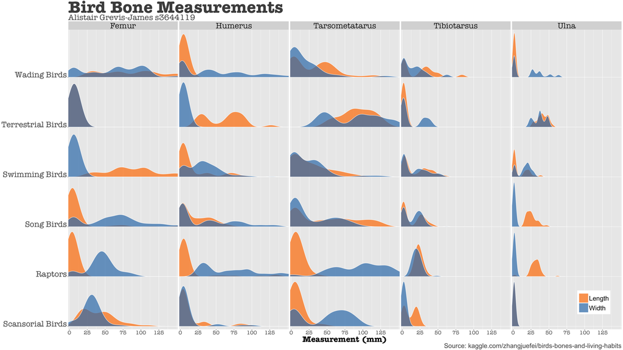

```r
birdsPlot <- ggplot(data = birdDS_Long,
                    aes(x=birdDS_Long$measurement,
                        y = birdType,
                        fill = measurementType))
birdsPlot <- birdsPlot + geom_density_ridges2(scale = 0.9, alpha=0.7, colour = 'white', size = 0.5) +
  labs(y = NULL, x = "Measurement (mm)",
       title = "Bird Bone Measurements",
       subtitle = "Alistair Grevis-James s3644119",
       caption="Source: kaggle.com/zhangjuefei/birds-bones-and-living-habits") +
  theme(plot.title=element_text(size=62,
                                    face="bold",
                                    family="American Typewriter",
                                    color="grey30"),
        plot.subtitle=element_text(size=30,
                                    family="American Typewriter",
                                    color="grey30"),
        plot.caption = element_text(size=24,
                                   color="grey30"),
        axis.title.x=element_text(vjust=0,
                                  face = "bold",
                                  family="American Typewriter",
                                  size=30),
        axis.text.y = element_text(vjust = 0,
                                   family="American Typewriter",
                                   size = 30),
        axis.text.x = element_text(size = 20,
                                   family="American Typewriter"),
        strip.text.x = element_text(size = 30,
                                   family="American Typewriter"),
        legend.text = element_text(size=24)) +
  guides(fill = guide_legend(keywidth = 2.5, keyheight = 2.5)) +
  #theme_minimal(base_size = 14) +
  scale_x_continuous(expand = c(0.01, 0), breaks = c(0, 25, 50, 75, 100, 125)) +
  coord_cartesian(xlim = c(0, 150)) +
  scale_y_discrete(expand = c(0.01, 0), labels=c("Scansorial Birds", "Raptors",
                                                   "Song Birds", "Swimming Birds",
                                                   "Terrestrial Birds", "Wading Birds")) +
  facet_grid(.~boneAlone) +
  theme(legend.title = element_blank()) +
  #theme(legend.position="bottom") +
  theme(legend.position = c(0.95, 0.09)) +
  scale_fill_manual(values = c("#ff7f00", "#377eb8"), labels=c("Length", "Width"))
birdsPlot
```

```r
#birdsPlot <- birdsPlot + theme(panel.spacing=grid::unit(0.3,"lines"),
#                       axis.text = element_text(size = rel(0.5)),
#                       strip.text = element_text(face = "bold", size=9),
#                       strip.text.x = element_text(margin = margin(.1, 0, .1, 0, "cm")),
#                       strip.text.y = element_text(margin = margin(0, .1, 0, .1, "cm")))
#birdsPlot + theme(panel.border = element_rect(fill = NA, colour = "grey30", size = 0.1))
```

[figure not shown]